# STAT 428: Homework 2: Random Number Generation and Sampling

Due Week 5, Saturday Feb 22 by 11:59 PM on Compass

## Exercise 1

**(a)** For each of the following commands, either explain why they should be errors, or explain the non-erroneous result.

```r
vector1 <- c("8", "12", "7", "32")
min(vector1)
sort(vector1)
sum(vector1)
```

**(b)** For the next series of commands, either explain their results, or why they should produce errors.

```r
vector2 <- c("5",7,12)
vector2[2] + vector2[3]
```

Since the first input is a character (denoted by quotations), R treats the whole vector `vector2` as a character string and treats the last two numeric inputs as characters. So the operation will show an error because the binary operation “`+`” does not work with non-numeric arguments.

```r
dataframe3 <- data.frame(z1="5",z2=5,z3=12)
dataframe3[1,2] + dataframe3[1,3]
```

```r
list4 <- list(z1="6", z2=42, z3="49", z4=126)
list4[[2]]+list4[[4]]
list4[2]+list4[4]
```

In this case, the first operation command produces the correct result 168 since `list4[[2]]+list4[[4]]` calls the values of the 2nd and 4th item in the list and sums them properly. However, the second command will show an error because `list4[2]` and `list4[4]` calls the 2nd and 4th elements in the list, which is an item with a tag and a value together and is hence treated by R as a non-numeric argument.

## Exercise 2

**Working with functions and operators.**

**(a)** The colon operator will create a sequence of integers in order. It is a special case of the function `seq()`. Using the help command `?seq` to learn about the function, design an expression that will give you the sequence of numbers from 1 to 20000 in increments of 582. Design another that will give you a sequence between 1 and 20000 that is exactly 52 numbers in length.

A sequence of numbers from 1 to 20000 in increments of 582 can be produced in R by the following code:

```r
seq(from = 1, to = 20000, by = 582)
```

```
##  [1]     1   583  1165  1747  2329  2911  3493  4075  4657  5239  5821  6403
## [13]  6985  7567  8149  8731  9313  9895 10477 11059 11641 12223 12805 13387
## [25] 13969 14551 15133 15715 16297 16879 17461 18043 18625 19207 19789
```

A sequence of numbers between 1 and 20000 that is exactly 52 numbers in length can be produced in the following way:

```r
seq(from = 1, to = 20000, length.out = 52)
```

```
##  [1]     1.0   393.1   785.3  1177.4  1569.5  1961.7  2353.8  2746.0  3138.1
## [10]  3530.2  3922.4  4314.5  4706.6  5098.8  5490.9  5883.1  6275.2  6667.3
## [19]  7059.5  7451.6  7843.7  8235.9  8628.0  9020.2  9412.3  9804.4 10196.6
## [28] 10588.7 10980.8 11373.0 11765.1 12157.3 12549.4 12941.5 13333.7 13725.8
## [37] 14117.9 14510.1 14902.2 15294.4 15686.5 16078.6 16470.8 16862.9 17255.0
## [46] 17647.2 18039.3 18431.5 18823.6 19215.7 19607.9 20000.0
```

**(b)** The function `rep()` repeats a vector some number of times. Explain the difference between `rep(1:5, times=6)` and `rep(1:5, each=6)`.

While `rep(1:5, times=6)` produces the vector {1, 2, 3, 4, 5} repeated 6 times in the same order as the original vector, `rep(1:5, each=6)` produces the same vector {1, 2, 3, 4, 5} with each element repeated 6 times in their own places. First output is {1, 2, 3, 4, 5, 1, 2, 3, 4, 5, 1, 2, 3, 4, 5, 1, 2, 3, 4, 5, 1, 2, 3, 4, 5, 1, 2, 3, 4, 5}, while the latter gives {1, 1, 1, 1, 1, 1, 2, 2, 2, 2, 2, 2, 3, 3, 3, 3, 3, 3, 4, 4, 4, 4, 4, 4, 5, 5, 5, 5, 5, 5}.

## Exercise 3

**Writing R functions.** Write an `R` function that accepts an $n \times n$ matrix $A$ as an argument and returns the trace of A, $trace(A) = \sum_{i=1}^n a_{ii}$. Include code that verifies that the function’s argument is indeed a square matrix. Also include comments that describe the function’s purpose, argument and output. The following code generates a list of 25 matrices of different dimensions. Apply your trace function to each matrix in this list.

```r
matrix.list <- lapply(1:25, FUN=function(x) {matrix(1:x^2, nrow=x, ncol=x)})
#The given list of matrices
```

```r
matrix.list <- lapply(1:25, FUN=function(x) {matrix(1:x^2, nrow=x, ncol=x)})
tr <- function(A){             #The trace function with A as the input.
  if(nrow(A)==ncol(A)){        #Checking whether input is a square matrix.
    n = nrow(A)
    rho = 0                    #Calculating trace recursively from definition.
    for(i in 1:n){
      rho = rho + A[i,i]
    }
    return(rho)                #Specifying the output.
  }
  else{
    print("The input is not a square matrix.")
  }
}
trace = rep(0,25)              #Calculating traces of the given matrices.
for(j in 1:25){
  trace[j] = tr(matrix.list[[j]])
}
trace
```

```
##  [1]    1    5   15   34   65  111  175  260  369  505  671  870 1105 1379 1695
## [16] 2056 2465 2925 3439 4010 4641 5335 6095 6924 7825
```

## Exercise 4

**Simulating Beta(3, 4) Random Variables: Which method is better?**

###Notes  
For each distribution, we write a function that:

- Has a counter for the number of accepted samples (call it `k`)
- Has a counter for the total number of iterations (call it `j`)
- Generate a Uniform(0,1) variable `u`
- Generate $x\sim g(x)$
- Use a while loop for while `k<10000`
- If $f(x)/g(x)>M*u$, accept `x`

Then the acceptance rate will be `k/j`

In this exercise, you will simulate Beta(3,4) random variables with target density
$$f(x) \propto x^2 \; (1-x)^{3}.$$
using the Accept/Reject Algorithm with two different instrumental densities.

- **[Method I]** Use uniform RV’s with instrumental density
  $$g_{1}(x) = 1,\quad 0 < x < 1.$$
  - you may use $M \approx 0.0346$.
  - to simulate from $g_{1}$ use the command `x <- runif(1)`.
- **[Method II]** Use the average of two uniform RV’s with instrumental density
  $$g_{2}(x) = 2 - |4x - 2|,\quad 0 < x <1.$$
  - you may use $M \approx 0.0264$.
  - the `R` function for absolute value is `abs`.
  - to simulate from $g_{2}$ use the command `x <- mean(runif(2))`.
- **[Question]** Which method is better? Answer this by responding to the following parts.

**(a)** Write a program that simulates 10,000 Beta(3,4) random variables using both methods.

**(b)** Compare the acceptance rates and decide which one is the better algorithm.

**(c)** Is it correct to use theoretical acceptance rate $\frac{1}{M}$? Why or why not?

**(d)** Graph histograms of your results.

**(e)** Summarizes your findings.

## Exercise 5

**Simulating a mixture distribution.**

Consider a density function of the form

$$f(x)=\sum_{k=1}^{K} \; \pi_{k} \; f_{k}(x)$$
where $\pi_{k} > 0$ for each $k$ and $\sum_{k=1}^{K} \pi_{k}=1$. Also assume that each $f_{k}$ is a probability density function for $k=1,2,...,K$.

Then it’s not hard to see that $f(x)$ is a probability density function. Furthermore, a random variable $X$ with pdf $f(x)$ is said to arise from a mixture of $K$ distributions. The constants $\pi_{k} > 0$ are called mixing probabilities or mixing weights.

To draw observations from this mixture distribution, we first choose a distribution, say $i$th distribution $f_i(x)$ to sample from based on the mixing probabilities and then generate from that $i$-th density like you normally would. The resulting variates would be a mixture of the $K$ distributions.

Now, do problem 3.12.

```r
r=4
b=2
lambda <- rgamma(1000, r, b)
y <- sapply(lambda, function(x) rexp(1,x))
```

`y` gives the required sample from the mixture distribution.

## Exercise 6

**$\chi^2$ distribution** There are many ways to generate a $\chi^2(\nu)$ distribution. Consider the following methods. For each method, plot a historgram of the resulting variables: do they all seem equally effective?

**(a)** Simulate 10000 pairs of random variables $(Z_1, Z_2)$, both from $\mathcal{N}(0,1)$ using the transformation method 4 under “3.4: Transformation methods” in the book. Use these pairs to generate 10000 $\chi^2(2)$ random variables.

###Notes (a)  
If $U_1,\cdots, U_n$ and $V_1,\cdots, V_n$ are uniform random variables, then:  
$Z_{i1}=\sqrt{-2\log U_i}\cos{(2\pi V_i)}$  
$Z_{i2}=\sqrt{-2\log V_i}\sin{(2\pi U_i)}$  
are independent standard normal random variables. Then $X_i=Z_{i1}^2+Z_{i2}^2$ are $\chi^2_2$.

**(b)** How does the exponential distribution relate to a $\chi^2(2)$ distribution? (Do a little research!) Generate 10000 random variables from a useful exponential distribution using CDF inversion for this case. Use them to calculate 10000 random variables from a $\chi^2(2)$ distribution.

###Notes (b)  
A $\chi^2(2)$ distribution is the same as an exponential distribution with a rate of $\frac{1}{2}$. So if we can generate 10000 samples from a Exp($\frac{1}{2}$) distribution, we will have 10000 samples from $\chi^2(2)$.

**(c)** Generate 10000 random variables from a gamma distribution such that the resulting variables will be $\chi^2(2)$. (You can use an r function to generate the gamma variables.)

###Notes (c)  
$\chi^2(2)$ is a special case of the gamma distribution. In this case, we should generate from $\Gamma(\frac{2}{2}, \frac{1}{2})=\Gamma(1, \frac{1}{2})$.

**For Exerise 7-10, do the following problems from the book 3.2, 3.3, 3.5, 3.9.**

## Exerise 7 (3.2)

The standard Laplace distribution has density $f(x) = \frac{1}{2} e^{-|x|}, \; x \in \mathbb{R}$. Then its distribution function can be written as
$$F(x) = \int_{- \infty}^x f(x) dx = \begin{cases}
\frac{1}{2} e^x \text{, } &x \le 0\\
1 - \frac{1}{2}e^{-x} \text{, } &x > 0
\end{cases}$$
Following this, the probability inverse transformation can be written as
$$F^{-1}(U) = \begin{cases}
\log[2U] \text{, } &U \le \frac{1}{2} \\
- \log [2(1-U)] \text{, } &U > \frac{1}{2}
\end{cases}$$
Using this we can generate a random sample of size 1000 by the inverse transform method and compare the sample distribution with the target distribution as follows:

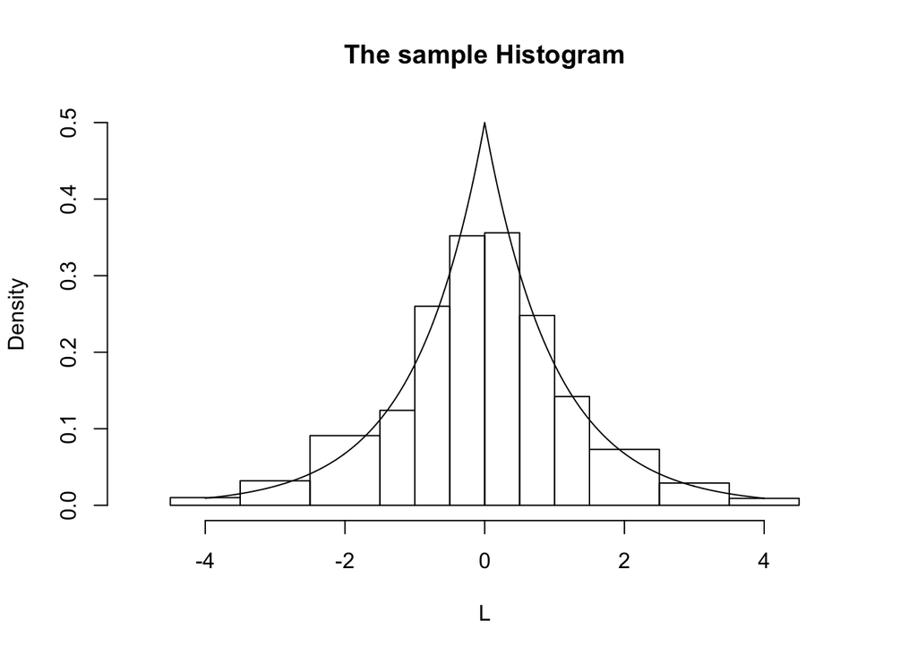

```r
u <- runif(1000)                                         #Generating standard uniform variates
L <- log(2*u)*(u <= 0.5) - log(2*(1-u))*(u > 0.5)        #Generating the random values from Laplace distribution
                                                         #using inverse transform method
#The vector L stores the simulated values
#Verifying whether the sampled density is close to the actual one
hist(L, probability = TRUE, xlim=c(-5,5), ylim=c(0,0.5), breaks = c(-Inf,-4.5,-3.5,-2.5,-1.5,-1,-0.5,0,0.5,1,1.5,2.5,3.5,4.5,Inf),main="The sample Histogram")
y <- seq(-4,4,0.01)
lines(y, 0.5*exp(-abs(y)))
```

## Exerise 9 (3.5)

```r
x <- c(0,1,2,3,4)
p <- c(0.1,0.2,0.2,0.2,0.3)
cp <- cumsum(p)
sample <- numeric(1000)
for(i in 1:1000){
  u <- runif(1)
  sample[i] <- min(which(u<=cp))
}
estp <- table(sample)/1000
se <- estp*(1-estp)/1000
round(rbind(p,estp,se),4)
```

```
##           1      2      3      4      5
## p    0.1000 0.2000 0.2000 0.2000 0.3000
## estp 0.1120 0.2080 0.2000 0.1890 0.2910
## se   0.0001 0.0002 0.0002 0.0002 0.0002
```

```r
samp <- sample(x, prob = p, replace = TRUE, size = 1000)
table(samp)/1000
```

```
## samp
##     0     1     2     3     4
## 0.095 0.194 0.176 0.197 0.338
```

## Exercise 10 (3.9)

```r
randf <- function(n){
  Usample1 = runif(n,-1,1)
  Usample2 = runif(n,-1,1)
  Usample3 = runif(n,-1,1)
  #if |U3| > |U1| and |U3| > |U2|
  index.U3 = (abs(Usample3)>abs(Usample1)) & (abs(Usample3)>abs(Usample2))
  #select
  Xsample = c(Usample2[index.U3],Usample3[!index.U3])
  return(Xsample)
}
```

Now we construct the histogram density estimate of 1000 random samples.

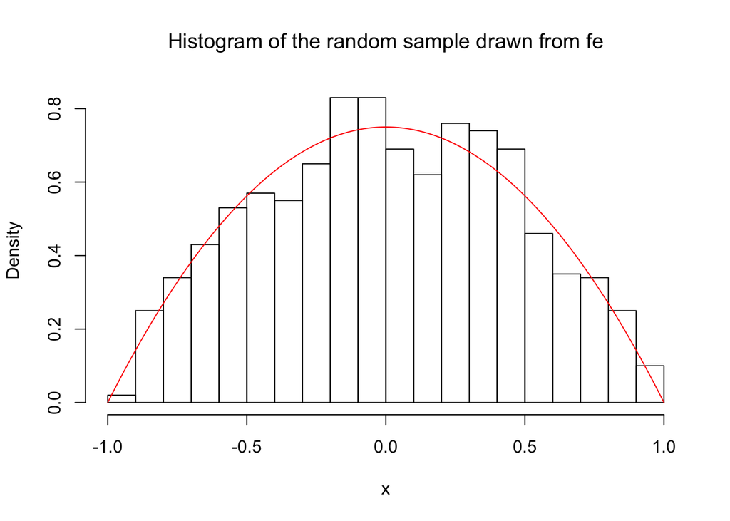

```r
hist(randf(1000),breaks = 20,freq=F,
     main=expression("Histogram of the random sample drawn from fe"),xlab = "x")
x=seq(-1,1,l=1000)
lines(x,3/4*(1-x^2),col="red")
```